# Exploración de datos Hidrológicos, tarea 02

### Importación de datos hidrólogicos de un archivo CSV

En esta sección se procede a importar los datos de los ríos Estrella y Banano de un archivo denominado como FDC.csv

```r
inp <- read.csv("FDC.csv", na.strings="")
```

### Gráfico de líneas del caudal de los ríos Estrella y Banano

Este gráfico hace una representación del volumen de los niveles de los caudales en los años de 1973 a 1983.

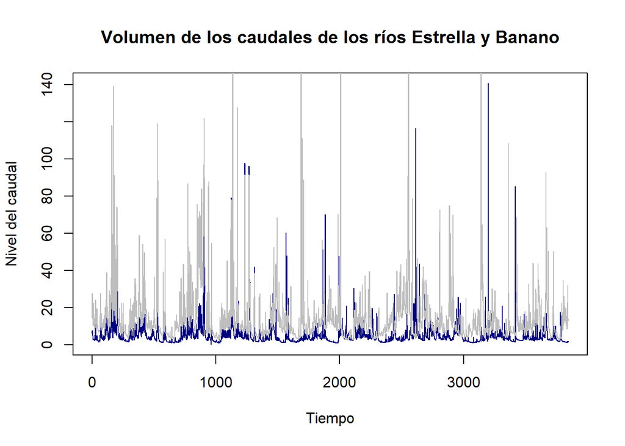

```r
plot(
  inp[,2],
  type = "l", col="navy blue",
  main = ("Volumen de los caudales de los ríos Estrella y Banano"),
  xlab = ("Tiempo"),
  ylab = ("Nivel del caudal")
)
  lines(inp[,3], col= "gray")
```

### Gráfico de barras del río Estrella

Este gráfico de barras brinda información del nivel del caudal respecto al agua por día.

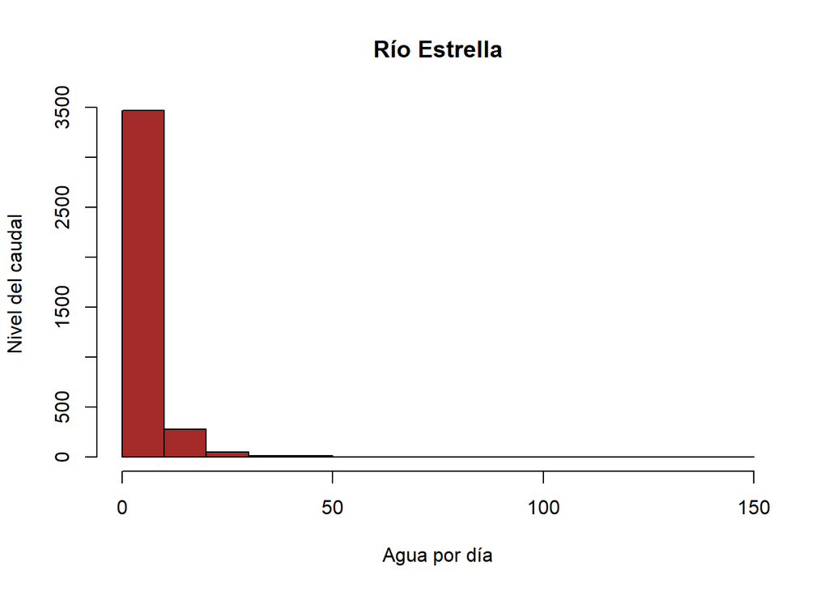

```r
  hist(inp[,2],
  main = ("Río Estrella"),
  height = inp$Estrella,
  names.arg = inp$Fecha,
  xlab = ("Agua por día"),
  ylab = ("Nivel del caudal"),
  col = ("Brown"))
```

### Gráfico de barras del río Banano

De igua manera este gráfico de barras ofrece información del nivel del caudal con respecto al agua que se da por día.

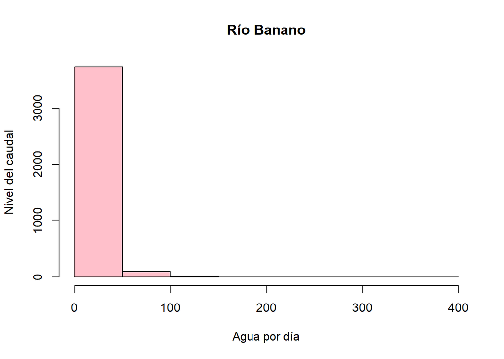

```r
  hist(inp[,3],
  main = ("Río Banano"),
  names.arg = inp$Fecha,
  xlab = ("Agua por día"),
  ylab = ("Nivel del caudal"),
  col = ("pink"))
```

### Determinar nombres a la columnas 1,2 y3

Se modifica los nombres de las colunmas 1,2 y 3. Así que la columna 1 se denominará Fecha, la columna 2 se le brindará el nombres de Estrella y la columna 3 se le determina como Banano.

```r
names(inp) <- c("fecha", "Estrella", "Banano")
```

### Gráfico de puntos del río Estrella

El gráfico corresponde a una visualización de puntos en base del nivel del caudal del río conforme el tiempo.

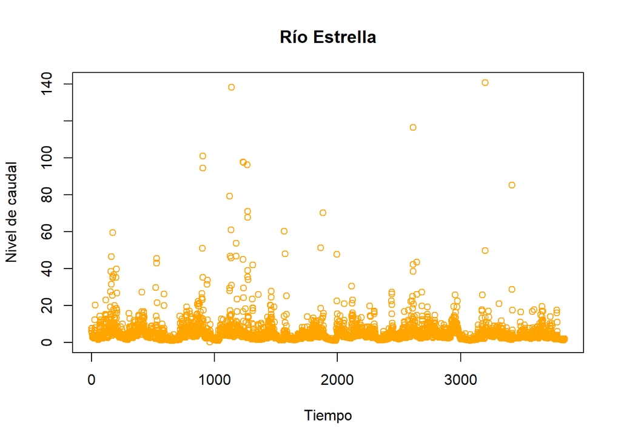

```r
plot(
  inp$Estrella,
  main = "Río Estrella",
  xlab = "Tiempo",
  ylab = "Nivel de caudal",
  col = "Orange"
)
```

### Gráfico de puntos del río Banano

El gráfico de igual manera que el anterio corresponde a una visualización de puntos en base del nivel del caudal del río conforme el tiempo.

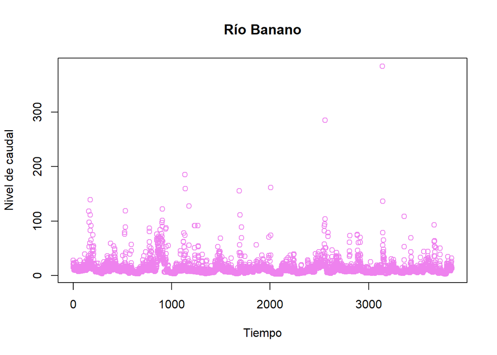

```r
plot(
  inp$Banano,
  main = "Río Banano",
  xlab = "Tiempo",
  ylab = "Nivel de caudal",
  col = "Violet"
)
```

### Conversión de la columna de Fecha

Se lleva a cabo una modificación de la columna de Fecha a la a la clase Date.

```r
Tempdate <- strptime(inp[,1], format = "%d/%m/%Y")
```

### Determinar el cálculo del caudal en un determinado período

Se determina el cálculo de los caudales de los ríos Estrella y Banano de manera anual.

```r
MAQ_Estrella <- tapply(inp[,2], format(Tempdate, format = "%Y"), FUN = sum)
MAQ_Banano <- tapply(inp[,3], format(Tempdate, format= "%Y"), FUN = sum)
```

### Exportar los archivos de MAQ Estrella y MAQ Banano

Se lleva a cabo una exportación de los datos de MAQ Estrella y MAQ Banano a un archivo del directorio correspondiente.

```r
write.csv(rbind(MAQ_Estrella,MAQ_Banano), file="MAQ.csv")
```

### Gráfico de líneas y puntos de los caudales del río Estrella y Banano

En este gráfico se visualiza líneas y puntos basados en una comparación del nivel del caudal de manera anual dado entre los años de 1973 a 1983, la línea representa el río Estrella y los puntos el río Banano.

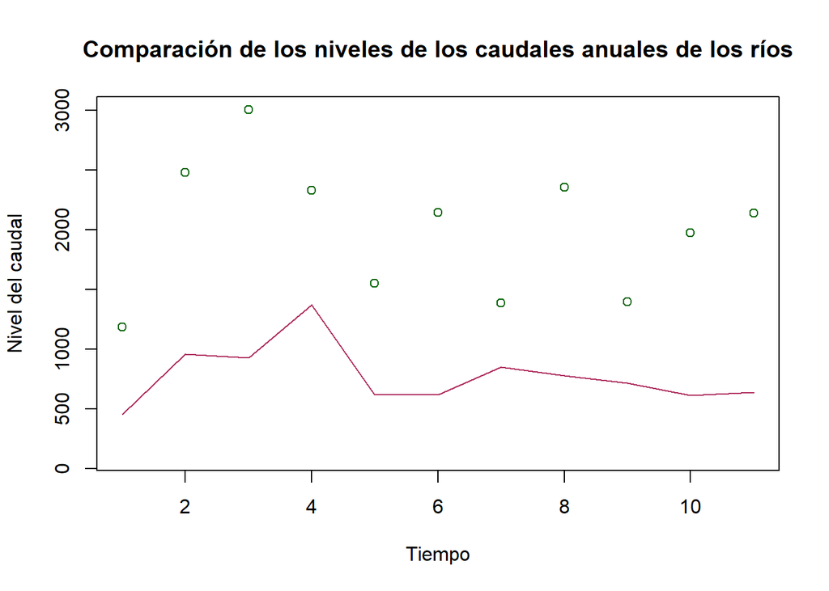

```r
plot(MAQ_Banano,
    ylim=c(100,3000),
    xlab= ("Tiempo"),
    ylab= ("Nivel del caudal"),
    main = ("Comparación de los niveles de los caudales anuales de los ríos"),
    col="dark green"
  )
lines(MAQ_Estrella, col="maroon")
```

### Determinar el cálculo del nivel caudal en un lapso determinado

Se determina el nivel del caudal de los ríos Estrella y Banano de forma mensual

```r
MMQ_Estrella <- tapply(inp[,2], format(Tempdate, format= "%m"), FUN=sum)
MMQ_Banano <- tapply(inp[,3], format(Tempdate, format= "%m"), FUN=sum)
```

### Análisis de correlación de los ríos Estrella y Banano

Se lleva a cabo para poder obtener un análisis de la relación que se presenta entre los ríos tmando en cuenta los causales y el tiempo

```r
corinp <- cor(inp[,2:3], method= "spearman")
```

### Gráfico de la relación dada entre los caudales de río Estrella y río Banano

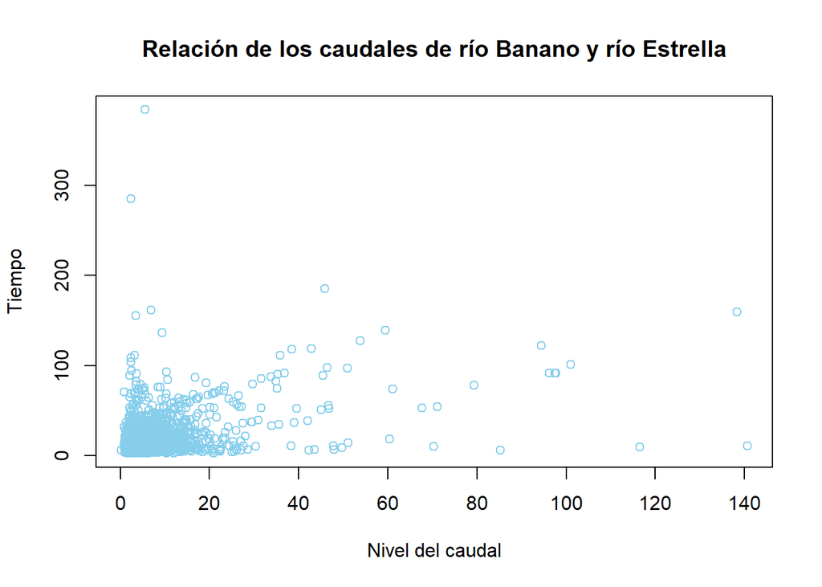

```r
plot(
  inp$Estrella,
  inp$Banano,
  xlab = ("Nivel del caudal"),
  ylab = ("Tiempo"),
  main = ("Relación de los caudales de río Banano y río Estrella"),
  col= ("sky blue")
)
```

### Gráficos de correlación de los ríos Estrella y Banano

Estos gráficos brindan distintas perpepciones de los análisis de los caudales relacionados con el tiempo.

```r
inp.lm <- lm(inp[,2]~inp[,3], data=inp)
summary(inp.lm)
```

```
##
## Call:
## lm(formula = inp[, 2] ~ inp[, 3], data = inp)
##
## Residuals:
##     Min      1Q  Median      3Q     Max
## -71.297  -2.267  -1.155   0.774 135.889
##
## Coefficients:
##             Estimate Std. Error t value Pr(>|t|)
## (Intercept)  2.70503    0.15174   17.83   <2e-16 ***
## inp[, 3]     0.19290    0.00707   27.28   <2e-16 ***
## ---
## Signif. codes:  0 '***' 0.001 '**' 0.01 '*' 0.05 '.' 0.1 ' ' 1
##
## Residual standard error: 7.025 on 3843 degrees of freedom
## Multiple R-squared:  0.1623, Adjusted R-squared:  0.162
## F-statistic: 744.4 on 1 and 3843 DF,  p-value: < 2.2e-16
```

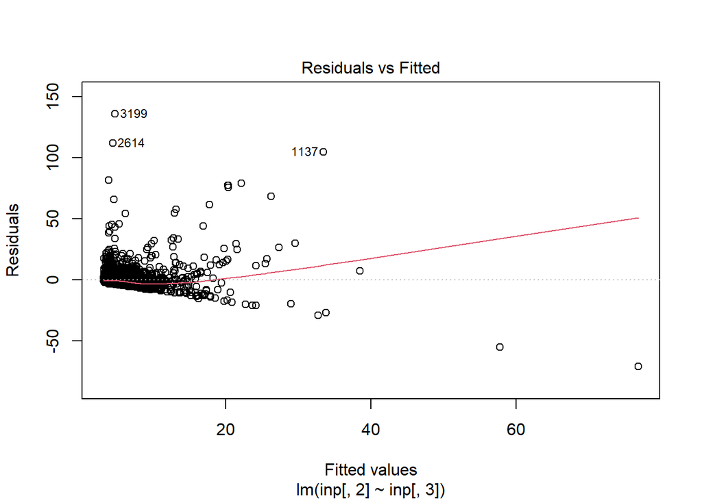

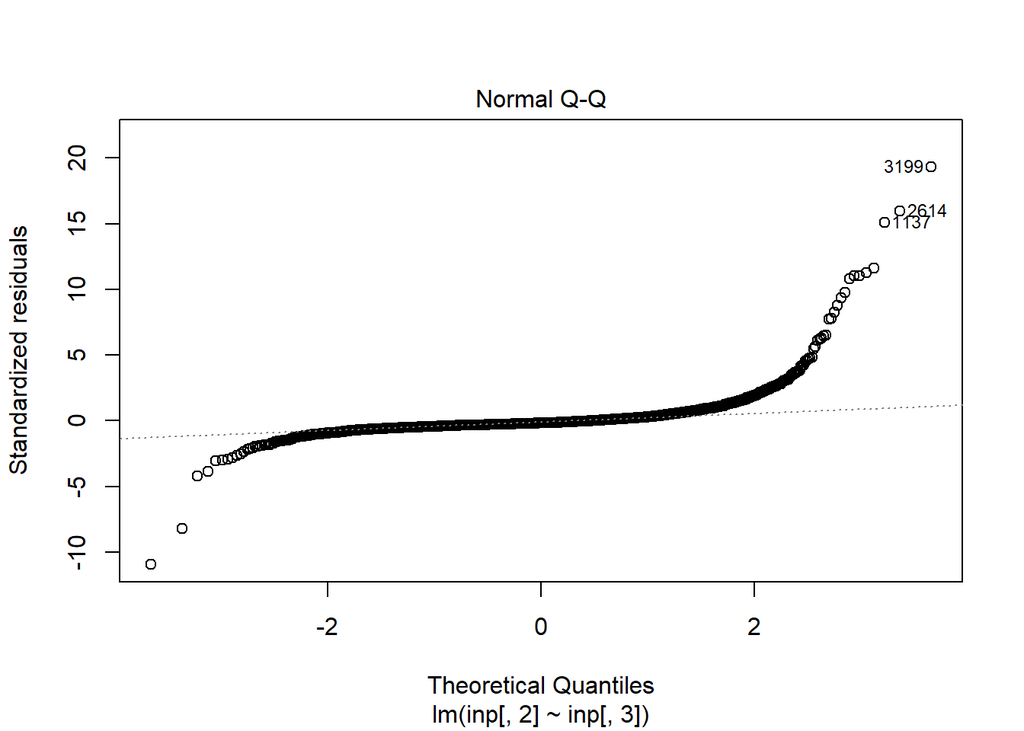

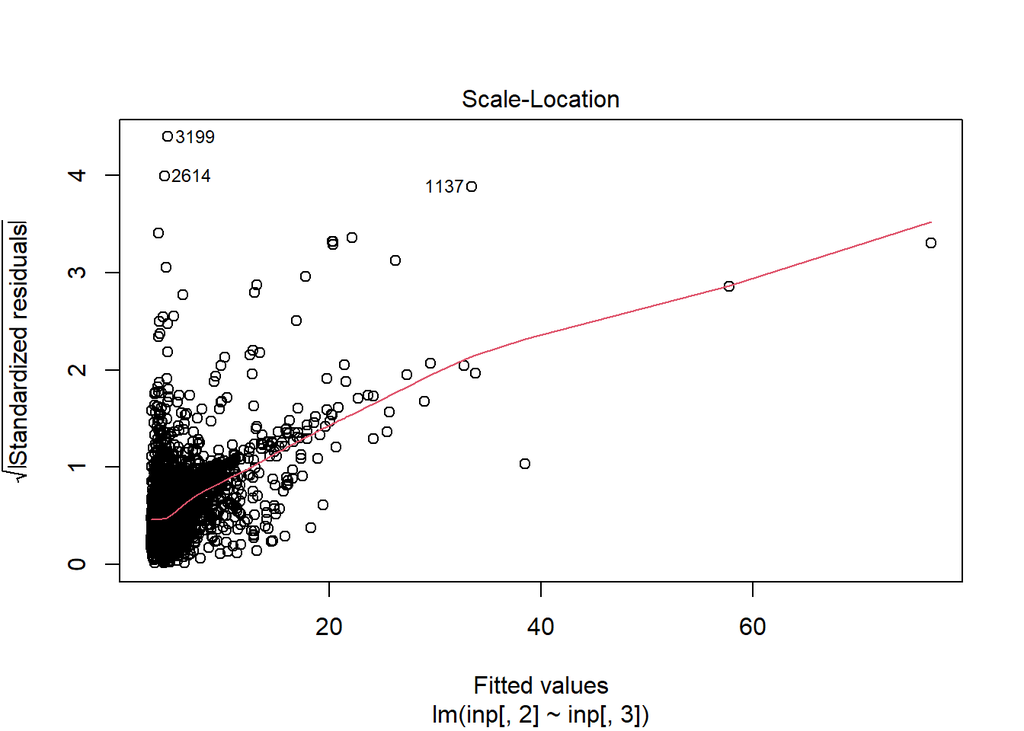

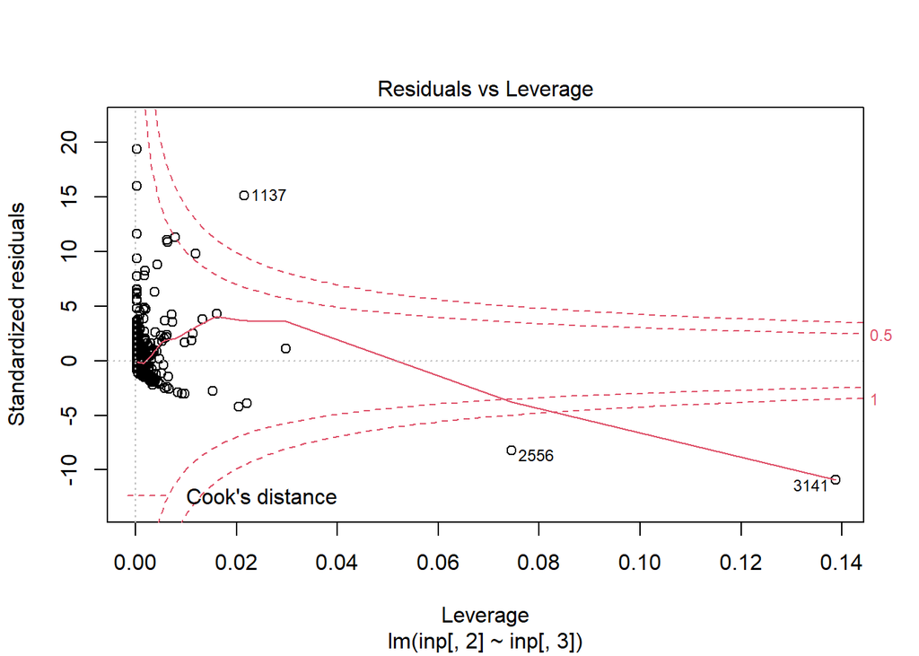

```r
plot(inp.lm)
```